# Final Case Study Proposal

Krischelle Joyner

9/12/2021

```r
shop <- read.csv("C:/Users/Krischelle/Documents/Krischelles most important stuff/Publish/Books and Learning/UTSA/Fall 2021 Classes/Data Analytics Applications/Case Studies/My Proposal/online_shoppers_intention.csv", header = TRUE)
```

```r
str(shop)
```

```
## 'data.frame':    12330 obs. of  18 variables:
##  $ Administrative         : int  0 0 0 0 0 0 0 1 0 0 ...
##  $ Administrative_Duration: num  0 0 0 0 0 0 0 0 0 0 ...
##  $ Informational          : int  0 0 0 0 0 0 0 0 0 0 ...
##  $ Informational_Duration : num  0 0 0 0 0 0 0 0 0 0 ...
##  $ ProductRelated         : int  1 2 1 2 10 19 1 0 2 3 ...
##  $ ProductRelated_Duration: num  0 64 0 2.67 627.5 ...
##  $ BounceRates            : num  0.2 0 0.2 0.05 0.02 ...
##  $ ExitRates              : num  0.2 0.1 0.2 0.14 0.05 ...
##  $ PageValues             : num  0 0 0 0 0 0 0 0 0 0 ...
##  $ SpecialDay             : num  0 0 0 0 0 0 0.4 0 0.8 0.4 ...
##  $ Month                  : chr  "Feb" "Feb" "Feb" "Feb" ...
##  $ OperatingSystems       : int  1 2 4 3 3 2 2 1 2 2 ...
##  $ Browser                : int  1 2 1 2 3 2 4 2 2 4 ...
##  $ Region                 : int  1 1 9 2 1 1 3 1 2 1 ...
##  $ TrafficType            : int  1 2 3 4 4 3 3 5 3 2 ...
##  $ VisitorType            : chr  "Returning_Visitor" "Returning_Visitor" "Returning_Visitor" "Returning_Visitor" ...
##  $ Weekend                : logi  FALSE FALSE FALSE FALSE TRUE FALSE ...
##  $ Revenue                : logi  FALSE FALSE FALSE FALSE FALSE FALSE ...
```

I’m removing any duplicate values.

```r
number_duplicate <- nrow(shop[duplicated(shop),])
shop <- shop[!duplicated(shop),]
str(shop)
```

```
## 'data.frame':    12205 obs. of  18 variables:
##  $ Administrative         : int  0 0 0 0 0 0 0 1 0 0 ...
##  $ Administrative_Duration: num  0 0 0 0 0 0 0 0 0 0 ...
##  $ Informational          : int  0 0 0 0 0 0 0 0 0 0 ...
##  $ Informational_Duration : num  0 0 0 0 0 0 0 0 0 0 ...
##  $ ProductRelated         : int  1 2 1 2 10 19 1 0 2 3 ...
##  $ ProductRelated_Duration: num  0 64 0 2.67 627.5 ...
##  $ BounceRates            : num  0.2 0 0.2 0.05 0.02 ...
##  $ ExitRates              : num  0.2 0.1 0.2 0.14 0.05 ...
##  $ PageValues             : num  0 0 0 0 0 0 0 0 0 0 ...
##  $ SpecialDay             : num  0 0 0 0 0 0 0.4 0 0.8 0.4 ...
##  $ Month                  : chr  "Feb" "Feb" "Feb" "Feb" ...
##  $ OperatingSystems       : int  1 2 4 3 3 2 2 1 2 2 ...
##  $ Browser                : int  1 2 1 2 3 2 4 2 2 4 ...
##  $ Region                 : int  1 1 9 2 1 1 3 1 2 1 ...
##  $ TrafficType            : int  1 2 3 4 4 3 3 5 3 2 ...
##  $ VisitorType            : chr  "Returning_Visitor" "Returning_Visitor" "Returning_Visitor" "Returning_Visitor" ...
##  $ Weekend                : logi  FALSE FALSE FALSE FALSE TRUE FALSE ...
##  $ Revenue                : logi  FALSE FALSE FALSE FALSE FALSE FALSE ...
```

I’m checking for any missing values, and I don’t find any.

```r
anyNA(shop)
```

```
## [1] FALSE
```

The “Month” attribute contains 10 months excluding January and April. Changing “June” to “Jun” with make plotting easier.

```r
shop$Month <- as.character(shop$Month)
shop$Month[shop$Month == "June"] <- "Jun"
shop$Month <- as.factor(shop$Month)
shop$Month = factor(shop$Month, levels = month.abb)
```

Exploratory Data Analysis

According to our six page attributes, customers visited different types of pages and spent most of their time looking at related products. Only a small fraction of visitors chose to dig into information about one product.The median values are as follows - # of Administrative pages visited: 1, Time spent in Administrative pages: 9, Number of Informational pages visited: 0, Time spent in Informational pages: 0, Number of ProductRelated pages visited: 18, Time spent in ProductRelated pages: 608.9

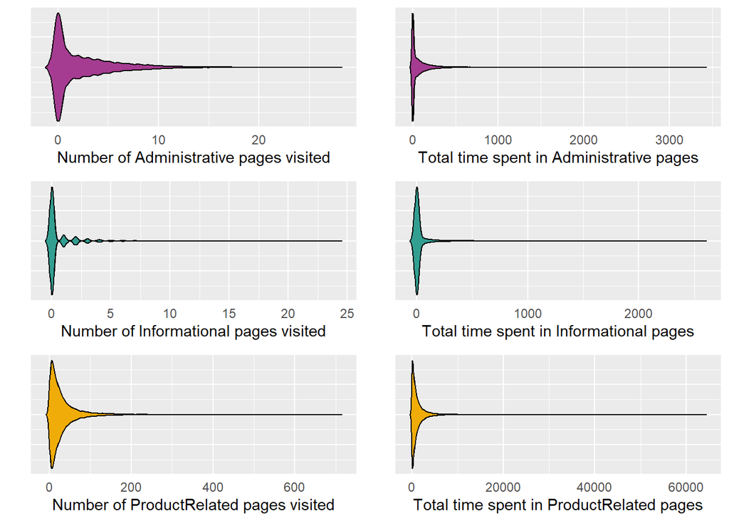

```r
plot1 <- ggplot(shop, aes(x=1, y=Administrative)) + geom_violin() + geom_violin(trim=FALSE, fill='#a53c91', color='black') + coord_flip() + labs(x = " ") + labs(y = "Number of Administrative pages visited") + theme(axis.text.y = element_blank(), axis.ticks = element_blank())
plot2 <- ggplot(shop, aes(x=1, y=Administrative_Duration)) + geom_violin() + geom_violin(trim=FALSE, fill='#a53c91', color='black') + coord_flip() + labs(x = " ") + labs(y = "Total time spent in Administrative pages") + theme(axis.text.y = element_blank(), axis.ticks = element_blank())
plot3 <- ggplot(shop, aes(x=1, y=Informational)) + geom_violin() + geom_violin(trim=FALSE, fill='#329f91', color='black') + coord_flip() + labs(x = " ") + labs(y = "Number of Informational pages visited") + theme(axis.text.y = element_blank(), axis.ticks = element_blank())
plot4 <- ggplot(shop, aes(x=1, y=Informational_Duration)) + geom_violin() +  geom_violin(trim=FALSE, fill='#329f91', color='black') + coord_flip() + labs(x = " ") + labs(y = "Total time spent in Informational pages") + theme(axis.text.y = element_blank(), axis.ticks = element_blank())
plot5 <- ggplot(shop, aes(x=1, y=ProductRelated)) + geom_violin() + geom_violin(trim=FALSE, fill='#f0ac09', color='black') + coord_flip() + labs(x = " ") + labs(y = "Number of ProductRelated pages visited") + theme(axis.text.y = element_blank(), axis.ticks = element_blank())
plot6 <- ggplot(shop, aes(x=1, y=ProductRelated_Duration)) + geom_violin() + geom_violin(trim=FALSE, fill='#f0ac09', color='black') + coord_flip() + labs(x = " ") + labs(y = "Total time spent in ProductRelated pages") + theme(axis.text.y = element_blank(), axis.ticks = element_blank())
grid.arrange(plot1, plot2, plot3, plot4, plot5, plot6, nrow = 3, ncol = 2)
```

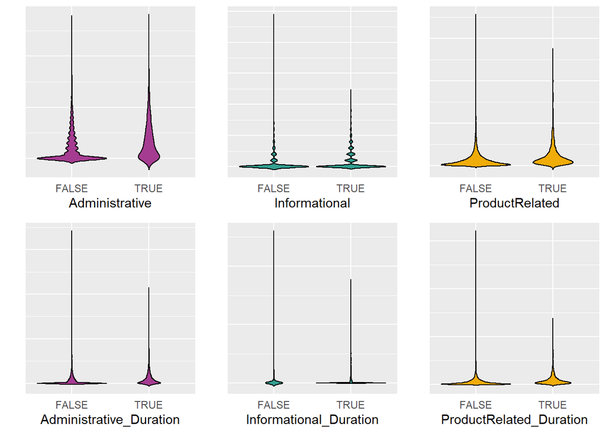

```r
plot1 <- ggplot(shop, aes(x=Revenue, y=Administrative)) + geom_violin() + geom_violin(trim=FALSE, fill='#a53c91', color='black') + labs(x = "Administrative") + labs(y = " ") + theme(axis.text.y = element_blank(), axis.ticks = element_blank())
plot4 <- ggplot(shop, aes(x=Revenue, y=Administrative_Duration)) + geom_violin() + geom_violin(trim=FALSE, fill='#a53c91', color='black') + labs(x = "Administrative_Duration") + labs(y = " ") + theme(axis.text.y = element_blank(), axis.ticks = element_blank())
plot2 <- ggplot(shop, aes(x=Revenue, y=Informational)) + geom_violin() + geom_violin(trim=FALSE, fill='#329f91', color='black') + labs(x = "Informational") + labs(y = " ") + theme(axis.text.y = element_blank(), axis.ticks = element_blank())
plot5 <- ggplot(shop, aes(x=Revenue, y=Informational_Duration)) + geom_violin() +  geom_violin(trim=FALSE, fill='#329f91', color='black') + labs(x = "Informational_Duration") + labs(y = " ") + theme(axis.text.y = element_blank(), axis.ticks = element_blank())
plot3 <- ggplot(shop, aes(x=Revenue, y=ProductRelated)) + geom_violin() + geom_violin(trim=FALSE, fill='#f0ac09', color='black') + labs(x = "ProductRelated") + labs(y = " ") + theme(axis.text.y = element_blank(), axis.ticks = element_blank())
plot6 <- ggplot(shop, aes(x=Revenue, y=ProductRelated_Duration)) + geom_violin() + geom_violin(trim=FALSE, fill='#f0ac09', color='black') + labs(x = "ProductRelated_Duration") + labs(y = " ") + theme(axis.text.y = element_blank(), axis.ticks = element_blank())
grid.arrange(plot1, plot2, plot3, plot4, plot5, plot6, nrow = 2, ncol = 3)
```

BounceRates, ExitRates, and PageValues provide insights into the behavior of customers viewing pages. There doesn’t appear to be a significant difference in revenue when examining customers’ BounceRates. On the other hand, when looking at ExitRates, the plot shows that customers who bought an item are in general less likely to leave than customers who did not buy an item, since they spent more time on the pages. The Pagevalues of non-purchasing customers are much lower than those of purchasing customers because they spend less time on related pages.

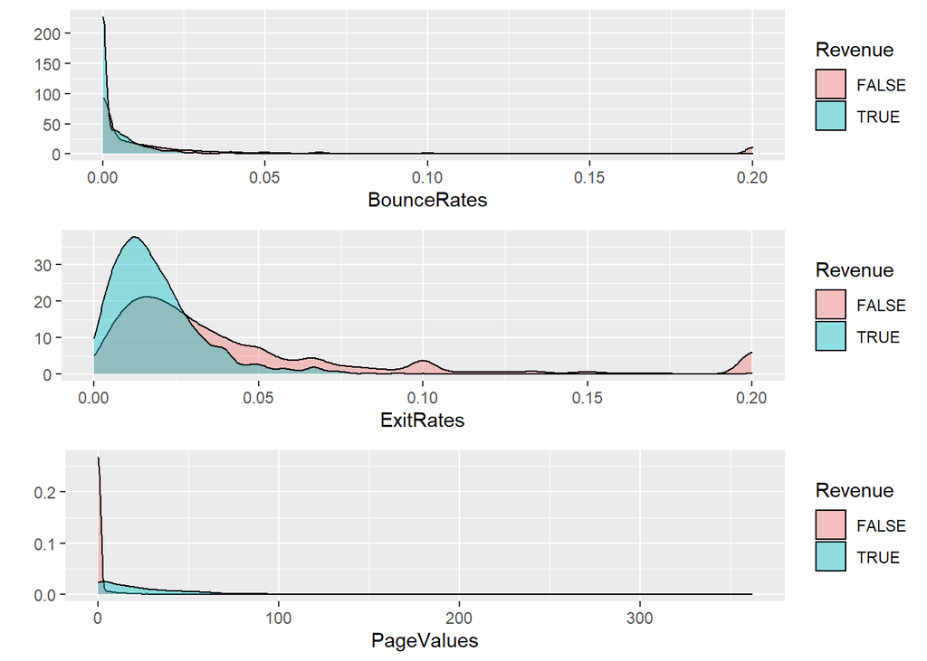

```r
plot1 <- ggplot(shop, aes(x=BounceRates, fill=Revenue)) + geom_density(alpha=0.4) + labs(y = " ")
plot2 <- ggplot(shop, aes(x=ExitRates, fill=Revenue)) + geom_density(alpha=0.4) + labs(y = " ")
plot3 <- ggplot(shop, aes(x=PageValues, fill=Revenue)) + geom_density(alpha=0.4) + labs(y = " ")
grid.arrange(plot1, plot2, plot3, nrow = 3)
```

On non-special days, purchasing customers were more likely to make purchases. This supports our observation that most customer decisions are not influenced by whether it is a special day or not.

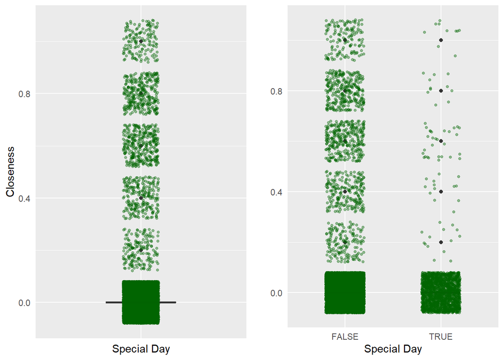

```r
plot1 <- ggplot(shop, aes(x = factor(1), y = SpecialDay)) + geom_boxplot(width = 0.4, fill = "white") + geom_jitter(color = "dark green", width = 0.1, size = 1, alpha=0.4) + labs(x = "Special Day") + labs(y = "Closeness") + theme(axis.text.x = element_blank(), axis.ticks = element_blank())
plot2 <- ggplot(shop, aes(x = Revenue, y = SpecialDay)) + geom_boxplot(width = 0.4, fill = "white") + geom_jitter(color = "dark green", width = 0.2, size = 1, alpha=0.4) + labs(x = "Special Day") + labs(y = " ") + theme(axis.ticks = element_blank())
grid.arrange(plot1, plot2, ncol = 2)
```

It should be noted that the month attribute displays only 10 of the 12 months, excluding January and April. The majority of shopping took place during March, May, November, and December. This might be due to these months being right before a new season.

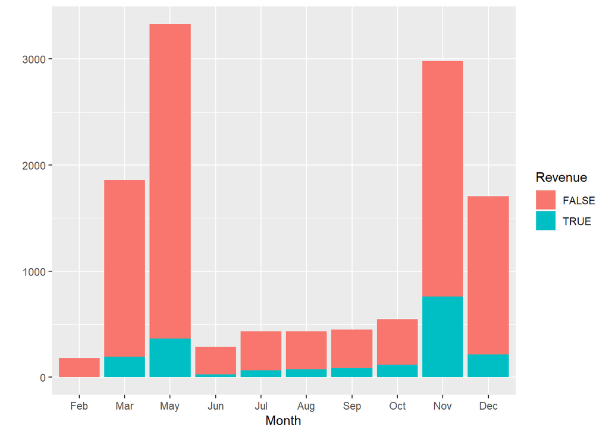

```r
plot <- ggplot(data.frame(shop), aes(Month, fill=Revenue)) + geom_bar() + labs(x = "Month") + labs(y = " ")
plot
```

Without knowing the numbers, the Operating Systems, Browser, Region, and Traffic Type attributes are not much help. The Weekend attribute shows more purchases on weekdays, while the Visitor Type is mostly return customers.

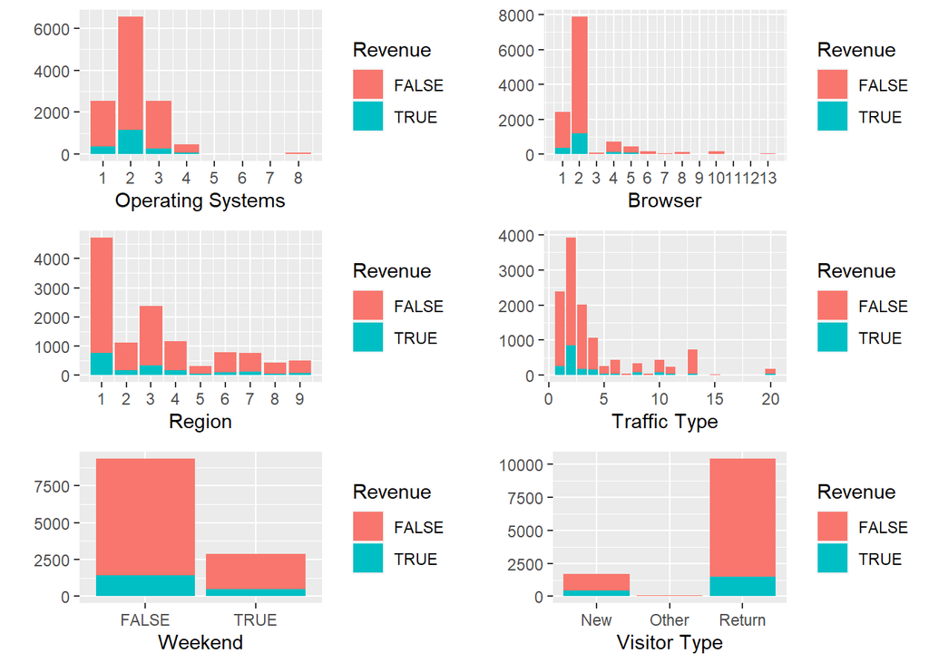

```r
plot1 <- ggplot(data.frame(shop), aes(OperatingSystems, fill=Revenue)) + geom_bar() + labs(x = "Operating Systems") + labs(y = " ") + scale_x_continuous(breaks = 1:8)
plot2 <- ggplot(data.frame(shop), aes(Browser, fill=Revenue)) + geom_bar() + labs(x = "Browser") + labs(y = " ") + scale_x_continuous(breaks = 1:13)
plot3 <- ggplot(data.frame(shop), aes(Region, fill=Revenue)) + geom_bar() + labs(x = "Region") + labs(y = " ") + scale_x_continuous(breaks = 1:9)
plot4 <- ggplot(data.frame(shop), aes(TrafficType, fill=Revenue)) + geom_bar() + labs(x = "Traffic Type") + labs(y = " ")
plot5 <- ggplot(data.frame(shop), aes(Weekend, fill=Revenue)) + geom_bar() + labs(x = "Weekend") + labs(y = " ")
plot6 <- ggplot(data.frame(shop), aes(VisitorType, fill=Revenue)) + geom_bar() + labs(x = "Visitor Type") + labs(y = " ") + scale_x_discrete(labels = c("New_Visitor" = "New", "Other" = "Other", "Returning_Visitor" = "Return"))
grid.arrange(plot1, plot2, plot3, plot4, plot5, plot6, nrow = 3, ncol = 2)
```

Checking correlations among variables in the data set. I see several high-correlated pairs like BounceRates/ExitRates and ProductRelated/ProductRelated_Duration that are evident; one of each pair might be dropped because of its importance to our model.

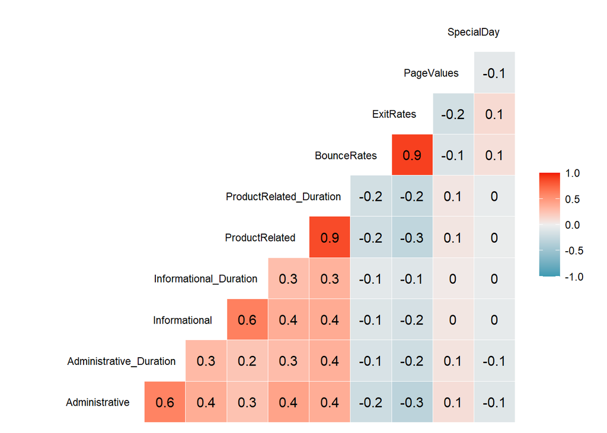

```r
corr_map <- ggcorr(shop[, 1:10], method=c("everything", "pearson"), label=TRUE, hjust = .90, size = 3, layout.exp = 2)
corr_map
```

######### Data Processing ###########################################

Updating the variables to factors and integers for later use in my models.

```r
shop$OperatingSystems = as.factor(shop$OperatingSystems)
shop$Browser = as.factor(shop$Browser)
shop$Region = as.factor(shop$Region)
shop$TrafficType = as.factor(shop$TrafficType)
shop$VisitorType = as.factor(shop$VisitorType)
shop$Weekend = as.integer(shop$Weekend)
shop$Revenue = as.integer(shop$Revenue)
```

I removed the following variables due to high correlations or limited information from the data set origin: ProductRelated, BounceRatesRates, OperatingSystems, Browser, Region, TrafficType.

```r
shop2 = shop
shop2 = shop2[c(1:4, 6, 8:11, 16:18)]
shop2$Revenue = as.factor(shop2$Revenue)
```

```r
str(shop2)
```

```
## 'data.frame':    12205 obs. of  12 variables:
##  $ Administrative         : int  0 0 0 0 0 0 0 1 0 0 ...
##  $ Administrative_Duration: num  0 0 0 0 0 0 0 0 0 0 ...
##  $ Informational          : int  0 0 0 0 0 0 0 0 0 0 ...
##  $ Informational_Duration : num  0 0 0 0 0 0 0 0 0 0 ...
##  $ ProductRelated_Duration: num  0 64 0 2.67 627.5 ...
##  $ ExitRates              : num  0.2 0.1 0.2 0.14 0.05 ...
##  $ PageValues             : num  0 0 0 0 0 0 0 0 0 0 ...
##  $ SpecialDay             : num  0 0 0 0 0 0 0.4 0 0.8 0.4 ...
##  $ Month                  : Factor w/ 12 levels "Jan","Feb","Mar",..: 2 2 2 2 2 2 2 2 2 2 ...
##  $ VisitorType            : Factor w/ 3 levels "New_Visitor",..: 3 3 3 3 3 3 3 3 3 3 ...
##  $ Weekend                : int  0 0 0 0 1 0 0 1 0 0 ...
##  $ Revenue                : Factor w/ 2 levels "0","1": 1 1 1 1 1 1 1 1 1 1 ...
```

```r
set.seed(123)
inTrain <- createDataPartition(y = shop2$Revenue, p=0.8, list=FALSE)
shop2.train <- shop2[inTrain, ]
shop2.test <- shop2[-inTrain, ]
```

Logistic Regression Model

```r
logit.m1 = glm(Revenue ~ ., data = shop2.train, family = binomial)
summary(logit.m1)
```

```
##
## Call:
## glm(formula = Revenue ~ ., family = binomial, data = shop2.train)
##
## Deviance Residuals:
##     Min       1Q   Median       3Q      Max
## -5.6401  -0.4630  -0.3324  -0.1658   3.4151
##
## Coefficients:
##                                Estimate Std. Error z value Pr(>|z|)
## (Intercept)                  -3.317e+00  6.486e-01  -5.113 3.16e-07 ***
## Administrative                4.296e-03  1.232e-02   0.349 0.727347
## Administrative_Duration      -1.126e-04  2.141e-04  -0.526 0.599028
## Informational                 2.155e-04  3.081e-02   0.007 0.994420
## Informational_Duration        1.809e-04  2.478e-04   0.730 0.465279
## ProductRelated_Duration       1.249e-04  1.750e-05   7.137 9.54e-13 ***
## ExitRates                    -1.833e+01  1.944e+00  -9.429  < 2e-16 ***
## PageValues                    8.532e-02  2.807e-03  30.394  < 2e-16 ***
## SpecialDay                    4.845e-02  2.588e-01   0.187 0.851454
## MonthMar                      1.110e+00  6.486e-01   1.711 0.087024 .
## MonthMay                      1.006e+00  6.417e-01   1.568 0.116951
## MonthJun                      1.555e+00  6.844e-01   2.273 0.023046 *
## MonthJul                      1.810e+00  6.632e-01   2.730 0.006341 **
## MonthAug                      1.744e+00  6.630e-01   2.631 0.008505 **
## MonthSep                      1.597e+00  6.608e-01   2.417 0.015635 *
## MonthOct                      1.492e+00  6.589e-01   2.264 0.023573 *
## MonthNov                      2.173e+00  6.433e-01   3.378 0.000731 ***
## MonthDec                      1.121e+00  6.488e-01   1.727 0.084151 .
## VisitorTypeOther             -1.863e-01  5.185e-01  -0.359 0.719356
## VisitorTypeReturning_Visitor -3.378e-01  9.593e-02  -3.521 0.000429 ***
## Weekend                       1.175e-01  7.973e-02   1.474 0.140427
## ---
## Signif. codes:  0 '***' 0.001 '**' 0.01 '*' 0.05 '.' 0.1 ' ' 1
##
## (Dispersion parameter for binomial family taken to be 1)
##
##     Null deviance: 8468.4  on 9764  degrees of freedom
## Residual deviance: 5678.5  on 9744  degrees of freedom
## AIC: 5720.5
##
## Number of Fisher Scoring iterations: 6
```

```r
logit.pred = predict(logit.m1, newdata = shop2.test, type = "response")
logit.pred.class = ifelse(logit.pred >= 0.5, 1, 0)
caret::confusionMatrix(as.factor(logit.pred.class), shop2.test$Revenue)
```

```
## Confusion Matrix and Statistics
##
##           Reference
## Prediction    0    1
##          0 1990  226
##          1   69  155
##
##                Accuracy : 0.8791
##                  95% CI : (0.8655, 0.8918)
##     No Information Rate : 0.8439
##     P-Value [Acc > NIR] : 4.243e-07
##
##                   Kappa : 0.4486
##
##  Mcnemar's Test P-Value : < 2.2e-16
##
##             Sensitivity : 0.9665
##             Specificity : 0.4068
##          Pos Pred Value : 0.8980
##          Neg Pred Value : 0.6920
##              Prevalence : 0.8439
##          Detection Rate : 0.8156
##    Detection Prevalence : 0.9082
##       Balanced Accuracy : 0.6867
##
##        'Positive' Class : 0
##
```

Logistic Regression Model with 5-fold Cross Validation

```r
train_ctrl = trainControl(method = "cv", number = 5)

logit.m2 = train(Revenue ~ ., data = shop2.train, method = "glm", trControl = train_ctrl)
summary(logit.m2)
```

```
##
## Call:
## NULL
##
## Deviance Residuals:
##     Min       1Q   Median       3Q      Max
## -5.6401  -0.4630  -0.3324  -0.1658   3.4151
##
## Coefficients: (2 not defined because of singularities)
##                                Estimate Std. Error z value Pr(>|z|)
## (Intercept)                  -2.196e+00  1.368e-01 -16.056  < 2e-16 ***
## Administrative                4.296e-03  1.232e-02   0.349 0.727347
## Administrative_Duration      -1.126e-04  2.141e-04  -0.526 0.599028
## Informational                 2.155e-04  3.081e-02   0.007 0.994420
## Informational_Duration        1.809e-04  2.478e-04   0.730 0.465279
## ProductRelated_Duration       1.249e-04  1.750e-05   7.137 9.54e-13 ***
## ExitRates                    -1.833e+01  1.944e+00  -9.429  < 2e-16 ***
## PageValues                    8.532e-02  2.807e-03  30.394  < 2e-16 ***
## SpecialDay                    4.845e-02  2.588e-01   0.187 0.851454
## MonthFeb                     -1.121e+00  6.488e-01  -1.727 0.084151 .
## MonthMar                     -1.066e-02  1.474e-01  -0.072 0.942382
## MonthApr                             NA         NA      NA       NA
## MonthMay                     -1.146e-01  1.387e-01  -0.826 0.408889
## MonthJun                      4.349e-01  2.633e-01   1.651 0.098656 .
## MonthJul                      6.895e-01  2.022e-01   3.411 0.000648 ***
## MonthAug                      6.239e-01  2.010e-01   3.104 0.001907 **
## MonthSep                      4.769e-01  1.933e-01   2.466 0.013650 *
## MonthOct                      3.712e-01  1.873e-01   1.982 0.047461 *
## MonthNov                      1.052e+00  1.201e-01   8.759  < 2e-16 ***
## MonthDec                             NA         NA      NA       NA
## VisitorTypeOther             -1.863e-01  5.185e-01  -0.359 0.719356
## VisitorTypeReturning_Visitor -3.378e-01  9.593e-02  -3.521 0.000429 ***
## Weekend                       1.175e-01  7.973e-02   1.474 0.140427
## ---
## Signif. codes:  0 '***' 0.001 '**' 0.01 '*' 0.05 '.' 0.1 ' ' 1
##
## (Dispersion parameter for binomial family taken to be 1)
##
##     Null deviance: 8468.4  on 9764  degrees of freedom
## Residual deviance: 5678.5  on 9744  degrees of freedom
## AIC: 5720.5
##
## Number of Fisher Scoring iterations: 6
```

```r
logit.pred2 = predict(logit.m2, newdata = shop2.test)
caret::confusionMatrix(logit.pred2, shop2.test$Revenue)
```

```
## Confusion Matrix and Statistics
##
##           Reference
## Prediction    0    1
##          0 1990  226
##          1   69  155
##
##                Accuracy : 0.8791
##                  95% CI : (0.8655, 0.8918)
##     No Information Rate : 0.8439
##     P-Value [Acc > NIR] : 4.243e-07
##
##                   Kappa : 0.4486
##
##  Mcnemar's Test P-Value : < 2.2e-16
##
##             Sensitivity : 0.9665
##             Specificity : 0.4068
##          Pos Pred Value : 0.8980
##          Neg Pred Value : 0.6920
##              Prevalence : 0.8439
##          Detection Rate : 0.8156
##    Detection Prevalence : 0.9082
##       Balanced Accuracy : 0.6867
##
##        'Positive' Class : 0
##
```

Logistic Regression Model with 5-fold repeated cross-validation

```r
train_ctrl2 = trainControl(method = "repeatedcv", number = 5)

logit.m3 = train(Revenue ~ ., data = shop2.train, method = "glm", trControl = train_ctrl2)
summary(logit.m3)
```

```
##
## Call:
## NULL
##
## Deviance Residuals:
##     Min       1Q   Median       3Q      Max
## -5.6401  -0.4630  -0.3324  -0.1658   3.4151
##
## Coefficients: (2 not defined because of singularities)
##                                Estimate Std. Error z value Pr(>|z|)
## (Intercept)                  -2.196e+00  1.368e-01 -16.056  < 2e-16 ***
## Administrative                4.296e-03  1.232e-02   0.349 0.727347
## Administrative_Duration      -1.126e-04  2.141e-04  -0.526 0.599028
## Informational                 2.155e-04  3.081e-02   0.007 0.994420
## Informational_Duration        1.809e-04  2.478e-04   0.730 0.465279
## ProductRelated_Duration       1.249e-04  1.750e-05   7.137 9.54e-13 ***
## ExitRates                    -1.833e+01  1.944e+00  -9.429  < 2e-16 ***
## PageValues                    8.532e-02  2.807e-03  30.394  < 2e-16 ***
## SpecialDay                    4.845e-02  2.588e-01   0.187 0.851454
## MonthFeb                     -1.121e+00  6.488e-01  -1.727 0.084151 .
## MonthMar                     -1.066e-02  1.474e-01  -0.072 0.942382
## MonthApr                             NA         NA      NA       NA
## MonthMay                     -1.146e-01  1.387e-01  -0.826 0.408889
## MonthJun                      4.349e-01  2.633e-01   1.651 0.098656 .
## MonthJul                      6.895e-01  2.022e-01   3.411 0.000648 ***
## MonthAug                      6.239e-01  2.010e-01   3.104 0.001907 **
## MonthSep                      4.769e-01  1.933e-01   2.466 0.013650 *
## MonthOct                      3.712e-01  1.873e-01   1.982 0.047461 *
## MonthNov                      1.052e+00  1.201e-01   8.759  < 2e-16 ***
## MonthDec                             NA         NA      NA       NA
## VisitorTypeOther             -1.863e-01  5.185e-01  -0.359 0.719356
## VisitorTypeReturning_Visitor -3.378e-01  9.593e-02  -3.521 0.000429 ***
## Weekend                       1.175e-01  7.973e-02   1.474 0.140427
## ---
## Signif. codes:  0 '***' 0.001 '**' 0.01 '*' 0.05 '.' 0.1 ' ' 1
##
## (Dispersion parameter for binomial family taken to be 1)
##
##     Null deviance: 8468.4  on 9764  degrees of freedom
## Residual deviance: 5678.5  on 9744  degrees of freedom
## AIC: 5720.5
##
## Number of Fisher Scoring iterations: 6
```

```r
logit.pred3 = predict(logit.m3, newdata = shop2.test)
caret::confusionMatrix(logit.pred3, shop2.test$Revenue)
```

```
## Confusion Matrix and Statistics
##
##           Reference
## Prediction    0    1
##          0 1990  226
##          1   69  155
##
##                Accuracy : 0.8791
##                  95% CI : (0.8655, 0.8918)
##     No Information Rate : 0.8439
##     P-Value [Acc > NIR] : 4.243e-07
##
##                   Kappa : 0.4486
##
##  Mcnemar's Test P-Value : < 2.2e-16
##
##             Sensitivity : 0.9665
##             Specificity : 0.4068
##          Pos Pred Value : 0.8980
##          Neg Pred Value : 0.6920
##              Prevalence : 0.8439
##          Detection Rate : 0.8156
##    Detection Prevalence : 0.9082
##       Balanced Accuracy : 0.6867
##
##        'Positive' Class : 0
##
```

```r
varImp(logit.m3)
```

```
## glm variable importance
##
##                               Overall
## PageValues                   100.0000
## ExitRates                     31.0079
## MonthNov                      28.8015
## ProductRelated_Duration       23.4638
## VisitorTypeReturning_Visitor  11.5652
## MonthJul                      11.2010
## MonthAug                      10.1930
## MonthSep                       8.0934
## MonthOct                       6.5001
## MonthFeb                       5.6607
## MonthJun                       5.4116
## Weekend                        4.8284
## MonthMay                       2.6948
## Informational_Duration         2.3799
## Administrative_Duration        1.7073
## VisitorTypeOther               1.1595
## Administrative                 1.1244
## SpecialDay                     0.5932
## MonthMar                       0.2148
## Informational                  0.0000
```

Random Forest Model

```r
set.seed(123)
RF1 <- train(Revenue ~ ., data = shop2.train, method='rf', importance=TRUE)
RF1$finalModel
```

```
##
## Call:
##  randomForest(x = x, y = y, mtry = min(param$mtry, ncol(x)), importance = TRUE)
##                Type of random forest: classification
##                      Number of trees: 500
## No. of variables tried at each split: 12
##
##         OOB estimate of  error rate: 10.1%
## Confusion matrix:
##      0   1 class.error
## 0 7866 372  0.04515659
## 1  614 913  0.40209561
```

```r
RF1Rev.preds <- predict(RF1, shop2.test)
confusionMatrix(RF1Rev.preds, shop2.test$Revenue)
```

```
## Confusion Matrix and Statistics
##
##           Reference
## Prediction    0    1
##          0 1950  163
##          1  109  218
##
##                Accuracy : 0.8885
##                  95% CI : (0.8754, 0.9007)
##     No Information Rate : 0.8439
##     P-Value [Acc > NIR] : 1.357e-10
##
##                   Kappa : 0.5511
##
##  Mcnemar's Test P-Value : 0.001311
##
##             Sensitivity : 0.9471
##             Specificity : 0.5722
##          Pos Pred Value : 0.9229
##          Neg Pred Value : 0.6667
##              Prevalence : 0.8439
##          Detection Rate : 0.7992
##    Detection Prevalence : 0.8660
##       Balanced Accuracy : 0.7596
##
##        'Positive' Class : 0
##
```

Random Forest Variable Importance

```r
varImp(RF1)
```

```
## rf variable importance
##
##   only 20 most important variables shown (out of 22)
##
##                              Importance
## PageValues                     100.0000
## ExitRates                       14.6857
## ProductRelated_Duration         10.6603
## Administrative                  10.4940
## MonthNov                         9.9824
## Administrative_Duration          8.5580
## VisitorTypeReturning_Visitor     7.1527
## MonthMar                         5.8718
## Informational                    5.4099
## Informational_Duration           5.4080
## MonthMay                         3.6753
## Weekend                          3.1246
## MonthFeb                         2.6622
## MonthApr                         1.8438
## MonthSep                         1.6207
## MonthJun                         1.4031
## SpecialDay                       1.3101
## MonthDec                         1.0979
## MonthOct                         1.0120
## VisitorTypeOther                 0.7724
```

Naive Bayes Model

```r
set.seed(123)
NB1 <- naiveBayes(Revenue ~ ., data = shop2.train)
```

```r
NB1.preds <- predict(NB1, newdata = shop2.test)
confusionMatrix(NB1.preds, shop2.test$Revenue)
```

```
## Confusion Matrix and Statistics
##
##           Reference
## Prediction    0    1
##          0 1819  164
##          1  240  217
##
##                Accuracy : 0.8344
##                  95% CI : (0.8191, 0.849)
##     No Information Rate : 0.8439
##     P-Value [Acc > NIR] : 0.9042613
##
##                   Kappa : 0.4189
##
##  Mcnemar's Test P-Value : 0.0001904
##
##             Sensitivity : 0.8834
##             Specificity : 0.5696
##          Pos Pred Value : 0.9173
##          Neg Pred Value : 0.4748
##              Prevalence : 0.8439
##          Detection Rate : 0.7455
##    Detection Prevalence : 0.8127
##       Balanced Accuracy : 0.7265
##
##        'Positive' Class : 0
##
```